# TO414 Group Project (Team 3)

2022-03-16

```r
# Import Libraries
library(neuralnet)
library(gmodels)
library(class)
library(caret)
library(kernlab)
library(C50)
library(MASS) #for stepAIC()
library(randomForest)
```

# Preliminary Analysis

## Load Dataset

```r
wq = read.csv('water_potability.csv')
```

## Getting Data Ready for Analysis

```r
# Fill NA values with Median Values to adjust data distribution to conform to rest of data that is available
wq$ph <- ifelse(is.na(wq$ph), median(wq$ph, na.rm = TRUE),wq$ph)
wq$Sulfate <- ifelse(is.na(wq$Sulfate), median(wq$Sulfate, na.rm = TRUE),wq$Sulfate)
wq$Trihalomethanes <- ifelse(is.na(wq$Trihalomethanes), median(wq$Trihalomethanes, na.rm = TRUE),wq$Trihalomethanes)
summary(wq)
```

```
##        ph            Hardness          Solids         Chloramines
##  Min.   : 0.000   Min.   : 47.43   Min.   :  320.9   Min.   : 0.352
##  1st Qu.: 6.278   1st Qu.:176.85   1st Qu.:15666.7   1st Qu.: 6.127
##  Median : 7.037   Median :196.97   Median :20927.8   Median : 7.130
##  Mean   : 7.074   Mean   :196.37   Mean   :22014.1   Mean   : 7.122
##  3rd Qu.: 7.870   3rd Qu.:216.67   3rd Qu.:27332.8   3rd Qu.: 8.115
##  Max.   :14.000   Max.   :323.12   Max.   :61227.2   Max.   :13.127
##     Sulfate       Conductivity   Organic_carbon  Trihalomethanes
##  Min.   :129.0   Min.   :181.5   Min.   : 2.20   Min.   :  0.738
##  1st Qu.:317.1   1st Qu.:365.7   1st Qu.:12.07   1st Qu.: 56.648
##  Median :333.1   Median :421.9   Median :14.22   Median : 66.622
##  Mean   :333.6   Mean   :426.2   Mean   :14.28   Mean   : 66.407
##  3rd Qu.:350.4   3rd Qu.:481.8   3rd Qu.:16.56   3rd Qu.: 76.667
##  Max.   :481.0   Max.   :753.3   Max.   :28.30   Max.   :124.000
##    Turbidity       Potability
##  Min.   :1.450   Min.   :0.0000
##  1st Qu.:3.440   1st Qu.:0.0000
##  Median :3.955   Median :0.0000
##  Mean   :3.967   Mean   :0.3901
##  3rd Qu.:4.500   3rd Qu.:1.0000
##  Max.   :6.739   Max.   :1.0000
```

```r
# Randomize the rows in the data (shuffling the rows)
set.seed(12345)
wq_random <- wq[sample(nrow(wq)),]

# Normalize the data
normalize <- function(x) {
  return ((x - min(x)) / (max(x) - min(x)))
}

# we are going to normalize everything
wq_norm <- as.data.frame(lapply(wq_random, normalize))
```

## Getting Train and Test Samples

```r
# Selects 10000 random rows for test data
set.seed(12345)
test_set <- sample(1:nrow(wq_norm), 650)

# Create a train set and test set
# First the predictors - all columns except the Potability column
wq_train <- wq_norm[-test_set, -match("Potability",names(wq_norm))]
wq_test <- wq_norm[test_set, -match("Potability",names(wq_norm))]

# Now the response (aka Labels) - only the Potability column
wq_train_labels <- wq_norm[-test_set, "Potability"]
wq_test_labels <- wq_norm[test_set, "Potability"]
```

# Our Models

## Logistic Regression

```r
# Initial Model With All Variables
lg_model1 <- glm(wq_train_labels ~ ., data = wq_train, family = binomial(link='logit'))
summary(lg_model1)
```

```
##
## Call:
## glm(formula = wq_train_labels ~ ., family = binomial(link = "logit"),
##     data = wq_train)
##
## Deviance Residuals:
##     Min       1Q   Median       3Q      Max
## -1.1713  -0.9969  -0.9485   1.3560   1.5286
##
## Coefficients:
##                 Estimate Std. Error z value Pr(>|z|)
## (Intercept)     -0.41896    0.52050  -0.805   0.4209
## ph               0.06478    0.38156   0.170   0.8652
## Hardness        -0.16002    0.33857  -0.473   0.6365
## Solids           0.59919    0.28754   2.084   0.0372 *
## Chloramines      0.27947    0.32153   0.869   0.3848
## Sulfate         -0.01965    0.40005  -0.049   0.9608
## Conductivity    -0.25871    0.28104  -0.921   0.3573
## Organic_carbon  -0.43201    0.31851  -1.356   0.1750
## Trihalomethanes  0.04815    0.31749   0.152   0.8795
## Turbidity       -0.10248    0.27288  -0.376   0.7073
## ---
## Signif. codes:  0 '***' 0.001 '**' 0.01 '*' 0.05 '.' 0.1 ' ' 1
##
## (Dispersion parameter for binomial family taken to be 1)
##
##     Null deviance: 3506.7  on 2625  degrees of freedom
## Residual deviance: 3498.5  on 2616  degrees of freedom
## AIC: 3518.5
##
## Number of Fisher Scoring iterations: 4
```

```r
# Predict Test Data with Logistical Regression q
lg_predict <- predict(lg_model1, newdata = wq_test, type = "response")

# Set the Threshold to the median of all predicted probabilities to adjust for the lower probabilities that are being calculated
threshold = median(lg_predict)
lg_predict <- ifelse(lg_predict > threshold, 1, 0)

# Evaluate Model Results
confusionMatrix(as.factor(lg_predict),as.factor(wq_test_labels), positive = "1")
```

```
## Confusion Matrix and Statistics
##
##           Reference
## Prediction   0   1
##          0 193 132
##          1 197 128
##
##                Accuracy : 0.4938
##                  95% CI : (0.4547, 0.533)
##     No Information Rate : 0.6
##     P-Value [Acc > NIR] : 1.000000
##
##                   Kappa : -0.0123
##
##  Mcnemar's Test P-Value : 0.000418
##
##             Sensitivity : 0.4923
##             Specificity : 0.4949
##          Pos Pred Value : 0.3938
##          Neg Pred Value : 0.5938
##              Prevalence : 0.4000
##          Detection Rate : 0.1969
##    Detection Prevalence : 0.5000
##       Balanced Accuracy : 0.4936
##
##        'Positive' Class : 1
##
```

```r
# Filtered Model with Significant Variables from Model 1 (just Solids)
lg_model2 <- glm(wq_train_labels ~ Solids, data = wq_train, family = binomial(link='logit'))
summary(lg_model2)
```

```
##
## Call:
## glm(formula = wq_train_labels ~ Solids, family = binomial(link = "logit"),
##     data = wq_train)
##
## Deviance Residuals:
##     Min       1Q   Median       3Q      Max
## -1.1407  -0.9933  -0.9602   1.3647   1.4661
##
## Coefficients:
##             Estimate Std. Error z value Pr(>|z|)
## (Intercept)  -0.6609     0.1079  -6.128 8.92e-10 ***
## Solids        0.5739     0.2811   2.042   0.0412 *
## ---
## Signif. codes:  0 '***' 0.001 '**' 0.01 '*' 0.05 '.' 0.1 ' ' 1
##
## (Dispersion parameter for binomial family taken to be 1)
##
##     Null deviance: 3506.7  on 2625  degrees of freedom
## Residual deviance: 3502.5  on 2624  degrees of freedom
## AIC: 3506.5
##
## Number of Fisher Scoring iterations: 4
```

```r
# Predict Test Data with Logistical Regression q
lg_predict2 <- predict(lg_model2, newdata = wq_test, type = "response")

# Set the Threshold to the median of all predicted probabilities to adjust for the lower probabilities that are being calculated
threshold2 = median(lg_predict2)
lg_predict2 <- ifelse(lg_predict2 > threshold2, 1, 0)

# Evaluate Model Results
confusionMatrix(as.factor(lg_predict2),as.factor(wq_test_labels), positive = "1")
```

```
## Confusion Matrix and Statistics
##
##           Reference
## Prediction   0   1
##          0 193 132
##          1 197 128
##
##                Accuracy : 0.4938
##                  95% CI : (0.4547, 0.533)
##     No Information Rate : 0.6
##     P-Value [Acc > NIR] : 1.000000
##
##                   Kappa : -0.0123
##
##  Mcnemar's Test P-Value : 0.000418
##
##             Sensitivity : 0.4923
##             Specificity : 0.4949
##          Pos Pred Value : 0.3938
##          Neg Pred Value : 0.5938
##              Prevalence : 0.4000
##          Detection Rate : 0.1969
##    Detection Prevalence : 0.5000
##       Balanced Accuracy : 0.4936
##
##        'Positive' Class : 1
##
```

## ANN Model

### With 1 Neuron

```r
# Create ANN Model
ann_wq_model <- neuralnet(formula = wq_train_labels ~ .,
                              data = wq_train, stepmax = 1e8)

# Plot ANN Model
#plot(ann_wq_model)
```

```r
## Evaluate Model Results
ann_wq_test_predict <- predict(ann_wq_model, wq_test, type = "response")

# Set the Threshold to the median of all predicted probabilities to adjust for the lower probabilities that are being calculated
threshold = median(ann_wq_test_predict)
ann_wq_test_predict <- ifelse(ann_wq_test_predict > threshold , 1, 0)


# Run Confusion Matrix
confusionMatrix(as.factor(ann_wq_test_predict),as.factor(wq_test_labels), positive = "1")
```

```
## Confusion Matrix and Statistics
##
##           Reference
## Prediction   0   1
##          0 202 123
##          1 188 137
##
##                Accuracy : 0.5215
##                  95% CI : (0.4823, 0.5605)
##     No Information Rate : 0.6
##     P-Value [Acc > NIR] : 0.9999784
##
##                   Kappa : 0.0431
##
##  Mcnemar's Test P-Value : 0.0002844
##
##             Sensitivity : 0.5269
##             Specificity : 0.5179
##          Pos Pred Value : 0.4215
##          Neg Pred Value : 0.6215
##              Prevalence : 0.4000
##          Detection Rate : 0.2108
##    Detection Prevalence : 0.5000
##       Balanced Accuracy : 0.5224
##
##        'Positive' Class : 1
##
```

### With 3 Neurons

```r
# Create ANN Model
ann_wq_model2 <- neuralnet(formula = wq_train_labels ~ .,
                              data = wq_train, hidden = 3, stepmax = 1e8)

# Plot ANN Model
#plot(ann_wq_model2)
```

```r
## Evaluate Model Results
ann_wq_test_predict2 <- predict(ann_wq_model2, wq_test, type= "response")

# Set the Threshold to the median of all predicted probabilities to adjust for the lower probabilities that are being calculated
threshold = median(ann_wq_test_predict2)
ann_wq_test_predict2 <- ifelse(ann_wq_test_predict2 > threshold , 1, 0)


# Run Confusion Matrix
confusionMatrix(as.factor(ann_wq_test_predict2),as.factor(wq_test_labels), positive = "1")
```

```
## Confusion Matrix and Statistics
##
##           Reference
## Prediction   0   1
##          0 229  96
##          1 161 164
##
##                Accuracy : 0.6046
##                  95% CI : (0.5659, 0.6424)
##     No Information Rate : 0.6
##     P-Value [Acc > NIR] : 0.4217
##
##                   Kappa : 0.2092
##
##  Mcnemar's Test P-Value : 6.546e-05
##
##             Sensitivity : 0.6308
##             Specificity : 0.5872
##          Pos Pred Value : 0.5046
##          Neg Pred Value : 0.7046
##              Prevalence : 0.4000
##          Detection Rate : 0.2523
##    Detection Prevalence : 0.5000
##       Balanced Accuracy : 0.6090
##
##        'Positive' Class : 1
##
```

### With 5 Neurons

```r
# Create ANN Model
ann_wq_model3 <- neuralnet(formula = wq_train_labels ~ .,
                              data = wq_train, hidden = 5, stepmax = 1e8)
```

```r
## Evaluate Model Results
ann_wq_test_predict3 <- predict(ann_wq_model3, wq_test, type= "response")

# Set the Threshold to the median of all predicted probabilities to adjust for the lower probabilities that are being calculated
threshold = median(ann_wq_test_predict3)
ann_wq_test_predict3 <- ifelse(ann_wq_test_predict3 > threshold , 1, 0)


# Run Confusion Matrix
confusionMatrix(as.factor(ann_wq_test_predict3),as.factor(wq_test_labels), positive = "1")
```

```
## Confusion Matrix and Statistics
##
##           Reference
## Prediction   0   1
##          0 241  84
##          1 149 176
##
##                Accuracy : 0.6415
##                  95% CI : (0.6033, 0.6785)
##     No Information Rate : 0.6
##     P-Value [Acc > NIR] : 0.0165
##
##                   Kappa : 0.2831
##
##  Mcnemar's Test P-Value : 2.756e-05
##
##             Sensitivity : 0.6769
##             Specificity : 0.6179
##          Pos Pred Value : 0.5415
##          Neg Pred Value : 0.7415
##              Prevalence : 0.4000
##          Detection Rate : 0.2708
##    Detection Prevalence : 0.5000
##       Balanced Accuracy : 0.6474
##
##        'Positive' Class : 1
##
```

## KNN Model

```r
# Create KNN Model
sqrt(nrow(wq))
```

```
## [1] 57.23635
```

```r
knn_pred <- knn(train = wq_train, test = wq_test,
                      cl = wq_train_labels, k=57)
```

```r
# Evaluate Model Results
confusionMatrix(as.factor(knn_pred), as.factor(wq_test_labels), positive = "1")
```

```
## Confusion Matrix and Statistics
##
##           Reference
## Prediction   0   1
##          0 380 236
##          1  10  24
##
##                Accuracy : 0.6215
##                  95% CI : (0.583, 0.659)
##     No Information Rate : 0.6
##     P-Value [Acc > NIR] : 0.1398
##
##                   Kappa : 0.078
##
##  Mcnemar's Test P-Value : <2e-16
##
##             Sensitivity : 0.09231
##             Specificity : 0.97436
##          Pos Pred Value : 0.70588
##          Neg Pred Value : 0.61688
##              Prevalence : 0.40000
##          Detection Rate : 0.03692
##    Detection Prevalence : 0.05231
##       Balanced Accuracy : 0.53333
##
##        'Positive' Class : 1
##
```

## SVM Model

```r
# Build SVM Model
svm_model <- ksvm(wq_train_labels ~ ., data = wq_train, kernel = "rbfdot")
svm_model
```

```
## Support Vector Machine object of class "ksvm"
##
## SV type: eps-svr  (regression)
##  parameter : epsilon = 0.1  cost C = 1
##
## Gaussian Radial Basis kernel function.
##  Hyperparameter : sigma =  0.0807167192359574
##
## Number of Support Vectors : 2184
##
## Objective Function Value : -1622.06
## Training error : 0.916595
```

```r
# Test Accuracy of SVM Model
## Evaluate Model Results
svm_model_pred <- predict(svm_model, wq_test)
svm_model_pred <- ifelse(svm_model_pred > 0.5 , 1, 0)

## Run Confusion Matrix
confusionMatrix(as.factor(svm_model_pred), as.factor(wq_test_labels), positive = "1")
```

```
## Confusion Matrix and Statistics
##
##           Reference
## Prediction   0   1
##          0 377 200
##          1  13  60
##
##                Accuracy : 0.6723
##                  95% CI : (0.6347, 0.7083)
##     No Information Rate : 0.6
##     P-Value [Acc > NIR] : 8.333e-05
##
##                   Kappa : 0.2243
##
##  Mcnemar's Test P-Value : < 2.2e-16
##
##             Sensitivity : 0.23077
##             Specificity : 0.96667
##          Pos Pred Value : 0.82192
##          Neg Pred Value : 0.65338
##              Prevalence : 0.40000
##          Detection Rate : 0.09231
##    Detection Prevalence : 0.11231
##       Balanced Accuracy : 0.59872
##
##        'Positive' Class : 1
##
```

## Decision Tree Model

```r
# Build Decision Tree Model
wq_tree_model <- C5.0(wq_train, as.factor(wq_train_labels), trials = 1)

# Decision Tree Predictions
dt_predict <- predict(wq_tree_model, wq_test)
summary(dt_predict)
```

```
##   0   1
## 554  96
```

```r
## Run Confusion Matrix
confusionMatrix(as.factor(dt_predict),as.factor(wq_test_labels), positive = "1")
```

```
## Confusion Matrix and Statistics
##
##           Reference
## Prediction   0   1
##          0 359 195
##          1  31  65
##
##                Accuracy : 0.6523
##                  95% CI : (0.6143, 0.6889)
##     No Information Rate : 0.6
##     P-Value [Acc > NIR] : 0.003454
##
##                   Kappa : 0.1905
##
##  Mcnemar's Test P-Value : < 2.2e-16
##
##             Sensitivity : 0.2500
##             Specificity : 0.9205
##          Pos Pred Value : 0.6771
##          Neg Pred Value : 0.6480
##              Prevalence : 0.4000
##          Detection Rate : 0.1000
##    Detection Prevalence : 0.1477
##       Balanced Accuracy : 0.5853
##
##        'Positive' Class : 1
##
```

[figure not shown]

```r
plot(wq_tree_model)
```

## Random Forest

```r
# Build Random Forest Model
rf_tree_model <- randomForest(wq_train, as.factor(wq_train_labels), trials = 100)

# Random Forest Predictions
rf_predict <- predict(rf_tree_model, wq_test)
summary(rf_predict)
```

```
##   0   1
## 531 119
```

```r
## Run Confusion Matrix
confusionMatrix(as.factor(rf_predict),as.factor(wq_test_labels), positive = "1")
```

```
## Confusion Matrix and Statistics
##
##           Reference
## Prediction   0   1
##          0 355 176
##          1  35  84
##
##                Accuracy : 0.6754
##                  95% CI : (0.6379, 0.7113)
##     No Information Rate : 0.6
##     P-Value [Acc > NIR] : 4.26e-05
##
##                   Kappa : 0.2565
##
##  Mcnemar's Test P-Value : < 2.2e-16
##
##             Sensitivity : 0.3231
##             Specificity : 0.9103
##          Pos Pred Value : 0.7059
##          Neg Pred Value : 0.6685
##              Prevalence : 0.4000
##          Detection Rate : 0.1292
##    Detection Prevalence : 0.1831
##       Balanced Accuracy : 0.6167
##
##        'Positive' Class : 1
##
```

## Level 2 Stacked Model

```r
# Create Combined Dataframe
combined_df <- data.frame(lg_predict, knn_pred, ann_wq_test_predict3, svm_model_pred, dt_predict, rf_predict, wq_test_labels)
```

```r
# Split Combined Dataframe into Test and Train Subsets
test_set <- sample(1:nrow(combined_df), 100)
combined_train <- combined_df[-test_set, ]
combined_test <- combined_df[test_set, ]
```

```r
# create a cost matrix
error_cost <- matrix(c(0, 1, 1.25, 0), nrow = 2)
error_cost
```

```
##      [,1] [,2]
## [1,]    0 1.25
## [2,]    1 0.00
```

```r
# apply the cost matrix to the tree
combined_cost <- C5.0(combined_train[-7], as.factor(combined_train$wq_test_labels),
                           costs = error_cost ,trials = 100)
combined_cost_pred <- predict(combined_cost, combined_test)

## Run Confusion Matrix
confusionMatrix(combined_cost_pred, as.factor(combined_test$wq_test_labels), positive = "1")
```

```
## Confusion Matrix and Statistics
##
##           Reference
## Prediction  0  1
##          0 56 22
##          1  7 15
##
##                Accuracy : 0.71
##                  95% CI : (0.6107, 0.7964)
##     No Information Rate : 0.63
##     P-Value [Acc > NIR] : 0.05835
##
##                   Kappa : 0.3212
##
##  Mcnemar's Test P-Value : 0.00933
##
##             Sensitivity : 0.4054
##             Specificity : 0.8889
##          Pos Pred Value : 0.6818
##          Neg Pred Value : 0.7179
##              Prevalence : 0.3700
##          Detection Rate : 0.1500
##    Detection Prevalence : 0.2200
##       Balanced Accuracy : 0.6471
##
##        'Positive' Class : 1
##
```

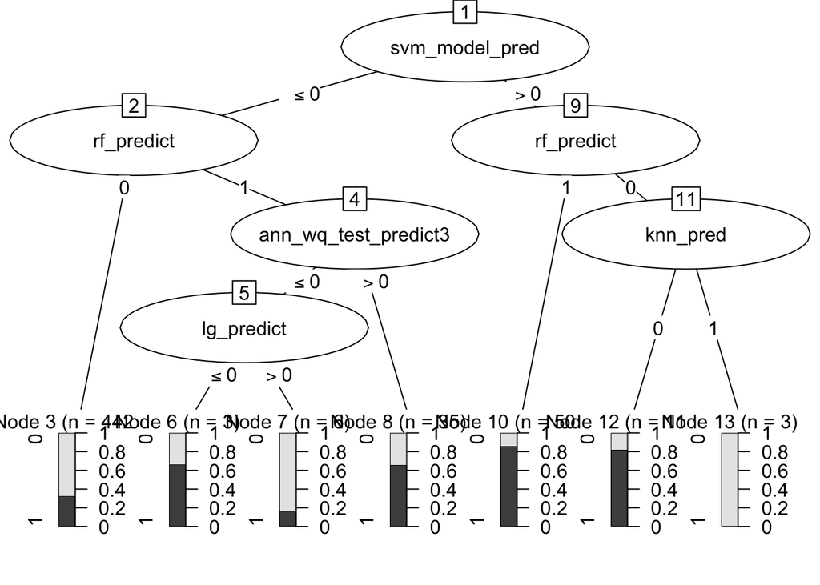

```r
plot(combined_cost)
```

# Conclusion

## Introduction

We want to use nine numerical variables to predict if the water is safe to drink for humans. The variables we are taking into account are the following:

- Ph
- Hardness
- Solids
- Chloramines
- Sulfate
- Conductivity
- Organic_carbon
- Trihalomethanes
- Turbidity

We substituted the NAs of Ph, Sulfate and Trihalomethanes with the respective medians.

We saw that our dataset was slightly skewed towards Zeros, being 1998 Zeros and 1278 Ones. Therefore, we tried to upsample the dataset, but the accuracy and kappa values of the model were strangely worse. Thus, we decided to continue our analyses without upsampling.

## Our Models

### Logistic model

- The model yields only one significant variable, namely solids.
- In order to convert the probabilities to 0s and 1s, we set the threshold to the median of the logistic predictions. We decided to have this approach because of the skewed distribution of 0s and 1s in the dataset.
- The accuracy is 49.38% and the kappa value is negative. This means that the variables have not a linear correlation and that the model performs worse than a random model.

### ANN Models

- ANN 1 Neuron: This model has an accuracy of 52% and a positive little kappa value (0.0431). The problem with this model is that there are plenty of false positives (188), so we will try to improve it by adding more hidden neurons.
- ANN 3 Neurons: By adding more neurons, the accuracy increases to 60% and the kappa value swelled to 0.2092. However, the false positives are still too many.
- ANN 5 Neurons: The ANN Model with 5 neurons delivers a slightly higher accuracy of 64% and a kappa value of 0.2831. The false positives are 149. They are still a lot, as proved by the precision ratio of only 54.15%.

### KNN

- The KNN yields similar results to the ANN but with an exception. The accuracy is about the same at 62.15% and the Kappa value is 0.078, but all the errors are shifted to the false negatives. The false positives, indeed, are only 10 and the precision metric is 70.59%, that is a huge improvement.

### SVM

- We used the rbfdot kernel that delivered and accuracy of 67.23% and a kappa value of 0.2243. There are 13 false positives and the precision metric is 82.2%. Until now, this is the best model we have.

### Decision Tree

- The accuracy of the model is 65.23% and the kappa value is 0.1905. We used only one trial because we realized that even if we tried with a greater number, the result would not change. The precision ratio is worse than SVM, amounting to 67.71%.

### Random Forest

- The accuracy of the model with 100 trials is 67.54%, with a kappa value of 0.2565. Even if the accuracy is higher than SVM’s one, the errors are more concentrated in false positives (that we want to avoid) if compared to SVM.

## Real World Applications and Takeaways

Water quality is determined by many different factors, most of which are included within our database. Different measurements of certain factors help us know if the water quality is safe enough to be drinkable. Bad water quality is not only a risk to humans but it is also a risk to the whole ecosystem. One in three people do not have access to safe drinking water and in many cases, such as the Flint water crisis, the lack of clean water isn’t realized right away. Around 829,000 people die per year due to the results of unsafe drinking water. Water at the end of the day is a basic human need and continuing to monitor water quality is important. Water isn’t only used for drinking but is also a necessity in many other industries. Poor water quality causes a negative effect on overall economic growth. Water plays a factor into every aspect of our life and there is a major importance in measuring and keeping track of water quality across the world.

Consequences of predicting water quality incorrectly can be incredibly damaging to both nearby populations and ecosystems. Model predictions can lead to both false negatives and false positives. In the case of water quality, a false positives is the most dangerous since that means that the model predicted dirty water as clean and safe to drink. We wanted to cut down on as many false positives as possible and therefore assigned a cost matrix to our final stacked model. This allowed us to cut down on the amount of false positives - we were able to cut them to just 10%. Consequences of an incorrect model can lead to health concerns for people who unknowingly drink contaminated water, a decrease in the natural biodiversity of the environment with contaminated water, and lasting negative impacts (costs, supply chain, etc) on the businesses that operate within the contaminated space. Our analysis of the water quality data and intent to make an accurate predictive model was essential to protect each of these at risk stakeholders.

## Business Applications

The ability to assess water quality can affect the decision-making of a multitude of organizations, from utility companies to conservation non-profits to bottled water businesses. By being able to assess water quality for a business who’s primary products or services pertain to water, they can utilize a stacked model like the one we’ve built to (1) encourage companies to enhance their internal water quality processing systems and (2) create a culture of transparency between company employees, investors, and customers. By doing so, stakeholders have the necessary knowledge to further establish their trust with these companies.We understand that organizations may already use complex models to determine the quality of water being consumed, including looking at the factors discussed in our model (such as chloramine and sulfate content), when building a model, there is always room for improvement.

If our model exhibited a higher prediction accuracy and demonstrated proof of reliability in experimental settings, there is opportunity to standardize model usage across companies and nonprofits. Standardization is likely most efficient when executed by a government agency, and the benefit of standardization is especially significant to society–the potability of the water being consumed will be more transparent, and individuals will know exactly what they are putting into their bodies. When trust is built between a customer and a utility company or bottled water company, those customers are likely to stay with that organization for a longer term, thus we may see decreased rates of customer churn and potentially increased consumption. However, some businesses, such as utility companies may know that the water they are processing is less safe, yet continue to distribute it to residents. So standardizing a model across utility companies may be hurtful to some, as consumers may switch to other businesses. Ultimately, this is beneficial for the good of society, as it can highlight water inequities across the US and potentially influence the government to prioritize accessibility to potable water.